# sd5answers

**Interest Rates**

1. There is a clear downwards trend in the interest rate over this time period, so a trend should be included in a unit root test equation for this time series.

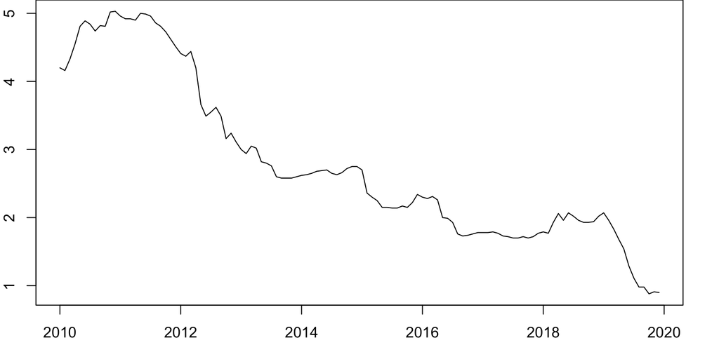

   ```r
   plot(Y)
   ```

2. Here is the `ur.df` command from the `urca` package. Note that a maximum of 13 lags is specified for the ADF test equation, with the lag length to be chosen by AIC. The maximum of 13 is chosen not for luck but because it is one greater than 12, which is a common default for monthly data. The idea is that we want the maximum lags to be “long enough”, i.e. such that the AIC chooses a lag length *less than* the pre-specified maximum. If the AIC chooses a lag length equal to our pre-specified maximum then it’s possible that the best lag length is still longer than that. For example, in this case if we saw the AIC chose a lag length of 13 then it would be prudent to increase the maximum further in case still more lags are required.

   ```r
   library(urca)
   adf <- ur.df(Y, type="trend", selectlags="AIC", lags=13)
   print(summary(adf))
   ```

   ```
   ###############################################
   # Augmented Dickey-Fuller Test Unit Root Test #
   ###############################################

   Test regression trend


   Call:
   lm(formula = z.diff ~ z.lag.1 + 1 + tt + z.diff.lag)

   Residuals:
        Min       1Q   Median       3Q      Max
   -0.37679 -0.04158  0.01395  0.04628  0.18469

   Coefficients:
                 Estimate Std. Error t value Pr(>|t|)
   (Intercept)  0.1663724  0.1006736   1.653 0.101550
   z.lag.1     -0.0444663  0.0209518  -2.122 0.036282 *
   tt          -0.0011252  0.0007144  -1.575 0.118372
   z.diff.lag1  0.3791295  0.0964434   3.931 0.000156 ***
   z.diff.lag2 -0.1818429  0.1017231  -1.788 0.076865 .
   z.diff.lag3  0.1898666  0.0971661   1.954 0.053490 .
   ---
   Signif. codes:  0 '***' 0.001 '**' 0.01 '*' 0.05 '.' 0.1 ' ' 1

   Residual standard error: 0.09498 on 100 degrees of freedom
   Multiple R-squared:  0.184, Adjusted R-squared:  0.1432
   F-statistic: 4.509 on 5 and 100 DF,  p-value: 0.0009511


   Value of test-statistic is: -2.1223 3.4902 2.5759

   Critical values for test statistics:
         1pct  5pct 10pct
   tau3 -3.99 -3.43 -3.13
   phi2  6.22  4.75  4.07
   phi3  8.43  6.49  5.47
   ```

   To explain this output, the ADF test equation is
   $$\begin{align}
   \Delta Y_t &= \beta_0 + \beta_1 t + \varphi Y_{t-1} \\
   & \quad + \psi_1 \Delta Y_{t-1} + \ldots + \psi_{p-1} \Delta Y_{t-p+1} + U_t
   \end{align}$$
   where $\beta_0$ is the intercept, $\beta_1$ the coefficient on the trend `tt`, $\varphi$ the coefficient on `z.lag.1` and $\psi_1,\ldots,\psi_{p-1}$ the coefficients on the `z.diff.lag` variables. The AIC has selected three lags $\Delta Y_{t-1}$, $\Delta Y_{t-2}$, $\Delta Y_{t-3}$ to include, i.e. $p=4$. Notice this test equation combines the two equations of our models in lectures into a single equation. For unit root testing purposes the equations
   $$\begin{align}
   Y_t &= \beta_0 + \beta_1 t + Z_t \\
   \Delta Z_t &= \varphi Z_{t-1} + \psi_1 \Delta Z_{t-1} +
   \ldots + \psi_{p-1} \Delta Z_{t-p+1} + U_t
   \end{align}$$
   are combined into the single equation above.

   The estimated ADF test equation is
   $$\widehat{\Delta Y_t} =
   0.166
   -0.001 t
   -0.044 Y_{t-1}
   + 0.379 \Delta Y_{t-1}
   -0.182 \Delta Y_{t-2}
   + 0.190 \Delta Y_{t-3}$$

   For unit root testing purposes, the relevant test statistic we use is the *t* statistic on `z.lag.1`, i.e. $t_\text{ADF}=-2.122$. The corresponding critical value is labelled `tau3`, so the 5% critical value is $-3.43$ (note, this is *not* from a *t* or normal distribution). The decision rule is
   $$\text{reject } H_0 \text{ if } t_{\text{ADF}} < \text{cv}.$$
   In this case $t_{\text{ADF}}>\text{cv}$, so $H_0$ is *not* rejected. The null hypothesis is that $Y_t$ has a unit root, i.e. requires differencing, so we proceed by taking a difference of `Y` for further analysis.
3. Accessing the statistic:

   ```r
   t_ADF <- adf@teststat[1]
   print(t_ADF)
   ```

   ```
   [1] -2.12231
   ```

   The *p*-value associated with this statistic can be computed in the following way:

   ```r
   p_ADF <- punitroot(t_ADF, trend="ct", statistic="t")
   print(p_ADF)
   ```

   ```
   [1] 0.5327231
   ```

   Note that these could be combined into a single command:

   ```r
   p_ADF <- punitroot(adf@teststat[1], trend="ct", statistic="t")
   print(p_ADF)
   ```

   ```
   [1] 0.5327231
   ```

   This *p*-value can be used in the usual way:
   $$\text{reject } H_0 \text{ if } p<0.05.$$
   Since $p=0.5327231>0.05$ in this case we do not reject $H_0$, which is necessarily the same conclusion as made using the critical value above.
4. Plotting the first difference:

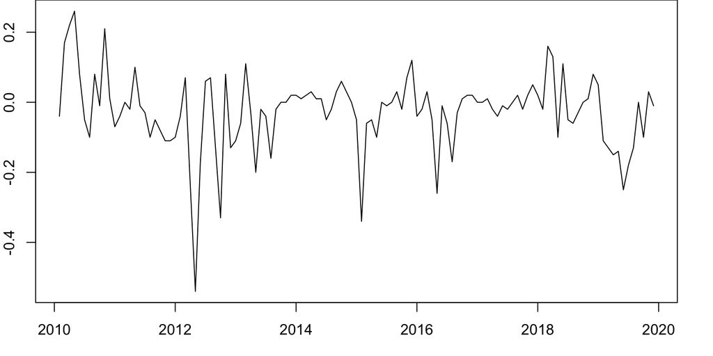

   ```r
   DY <- diff(Y)
   plot(DY)
   ```

   After taking the first difference the evidence of the linear trend has disappeared. We carry out a unit root test on $\Delta Y_t$ to see if a second difference is required.

   ```r
   adf <- ur.df(DY, type="drift", selectlags="AIC", lags=13)
   print(adf@testreg$coefficients)
   ```

   ```
                  Estimate Std. Error    t value     Pr(>|t|)
   (Intercept) -0.02461579 0.01082278 -2.2744412 2.505398e-02
   z.lag.1     -0.64041853 0.13686853 -4.6790781 8.966145e-06
   z.diff.lag1  0.01912893 0.11592935  0.1650051 8.692698e-01
   z.diff.lag2 -0.17467768 0.09843169 -1.7746081 7.897555e-02
   ```

   It’s worth checking again the AIC-selected lag length relative to the maximum lags – in this case two lags are selected, which is less than the specified maximum of 13.

   ```r
   p_ADF <- punitroot(adf@teststat[1], trend="c", statistic="t")
   print(p_ADF)
   ```

   ```
   [1] 8.833743e-05
   ```

   The *p*-value satisfies $p=8.8e-05<0.05$, so $H_0$ is rejected and we conclude there is no need to difference the time series a second time.
5. The `ndiffs` command concludes that one difference is required, consistent with the tests we just did.

   ```r
   library(forecast)
   nd <- ndiffs(Y, test="adf", type="trend", selectlags="AIC", lags=13)
   print(nd)
   ```

   ```
   [1] 1
   ```